# Feed Forward Propagation

Feed Forward: Burn the Past, Forge the Future

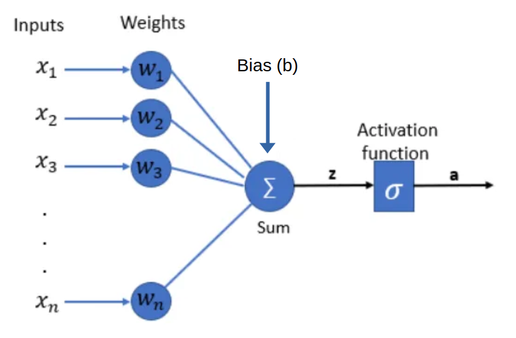

Figure 1. Perceptron

we know,  
=> $z = w_1x_1+ w_2x_2+ ... + w_nx_n+ b$

in matrix form,

$\text{W = } \begin{bmatrix} w_1 \\ w_2 \\ . \\ . \\ . \\ w_n \end{bmatrix} , \quad \text{X = } \begin{bmatrix} x_1\\ x_2\\ . \\ . \\ . \\ x_n \end{bmatrix} , \quad \text{b = } \begin{bmatrix} b\\ \end{bmatrix}$

=> $z = \text{W}^T\text{X}+ \text{b}$

where, $\text{W}$ is weight matrix, $\text{X}$ is input matrix and $\text{b}$ is bias matrix.

### **Considering a Neural Network**

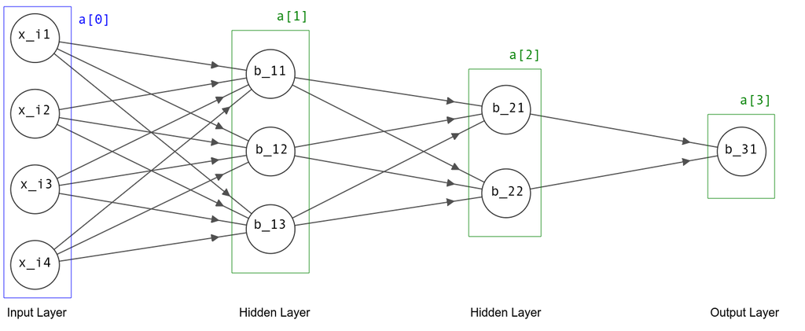

Figure 2. A Neural Network [3,2,1]

#### (i) **For Layer #1**

$\text{W}_1 = \begin{bmatrix} w_{11}^1 & w_{12}^1 & w_{13}^1\\ \\ w_{21}^1 & w_{22}^1 & w_{23}^1\\ \\ w_{31}^1 & w_{32}^1 & w_{33}^1\\ \\ w_{41}^1 & w_{42}^1 & w_{43}^1 \end{bmatrix} , \quad \text{X}_1 = \begin{bmatrix} x_{i1} \\ \\ x_{i2} \\ \\ x_{i3} \\ \\ x_{i4} \\ \end{bmatrix} , \quad \text{b}_1 = \begin{bmatrix} b_{11}\\ \\ b_{12}\\ \\ b_{13} \end{bmatrix}$

We know,

=> $z_1 = \text{W}_1^T\text{X}_1+ \text{b}_1 \quad$ and $\quad \text{W}_1^T = \begin{bmatrix} w_{11}^1 & w_{21}^1 & w_{31}^1 & w_{41}^1 \\ w_{12}^1 & w_{22}^1 & w_{32}^1 & w_{42}^1 \\ w_{13}^1 & w_{23}^1 & w_{33}^1 & w_{43}^1 \end{bmatrix}$

=> $z_1 = \begin{bmatrix} (w_{11}^1 x_{i1} + w_{21}^1 x_{i2} + w_{31}^1 x_{i3} + w_{41}^1 x_{i4}) + b_{11} \\ \\ (w_{12}^1 x_{i1} + w_{22}^1 x_{i2} + w_{32}^1 x_{i3} + w_{42}^1 x_{i4}) + b_{12} \\ \\ (w_{13}^1 x_{i1} + w_{23}^1 x_{i2} + w_{33}^1 x_{i3} + w_{43}^1 x_{i4}) + b_{13} \end{bmatrix}$

=> $\sigma({z_1}) = \sigma \big( \begin{bmatrix} (w_{11}^1 x_{i1} + w_{21}^1 x_{i2} + w_{31}^1 x_{i3} + w_{41}^1 x_{i4}) + b_{11} \\ \\ (w_{12}^1 x_{i1} + w_{22}^1 x_{i2} + w_{32}^1 x_{i3} + w_{42}^1 x_{i4}) + b_{12} \\ \\ (w_{13}^1 x_{i1} + w_{23}^1 x_{i2} + w_{33}^1 x_{i3} + w_{43}^1 x_{i4}) + b_{13} \end{bmatrix} \big) = \begin{bmatrix}O_{11}\\O_{12}\\O_{13}\end{bmatrix} = \text{a}^\text{[1]}$

#### (ii) **For Layer #2**

$\text{W}_2 = \begin{bmatrix} w_{11}^2 & w_{12}^2\\ \\ w_{21}^2 & w_{22}^2\\ \\ w_{31}^2 & w_{32}^2 \end{bmatrix} , \quad \text{X}_2 = \begin{bmatrix}O_{11}\\O_{12}\\O_{13}\end{bmatrix} , \quad \text{b}_2 = \begin{bmatrix} b_{21}\\ \\ b_{22} \end{bmatrix}$

Again,

=> $z_2 = \text{W}_2^T\text{X}_2 + \text{b}_2 \quad$ and $\quad \text{W}_2^T = \begin{bmatrix} w_{11}^2 & w_{21}^2 & w_{31}^2 \\ w_{12}^2 & w_{22}^2 & w_{32}^2 \end{bmatrix}$

=> $\sigma({z_2}) = \sigma \big( \begin{bmatrix} (w_{11}^2 O_{11} + w_{21}^2 O_{12} + w_{31}^2 O_{13}) + b_{21} \\ (w_{12}^2 O_{11} + w_{22}^2 O_{12} + w_{32}^2 O_{13}) + b_{22} \end{bmatrix} \big) = \begin{bmatrix}O_{21}\\O_{22}\end{bmatrix} = \text{a}^\text{[2]}$

#### (iii) **For Layer #3**

$\text{W}_3 = \begin{bmatrix} w_{11}^3\\ \\ w_{21}^3 \end{bmatrix} , \quad \text{X}_3 = \begin{bmatrix}O_{21}\\O_{22}\end{bmatrix} , \quad \text{b}_3 = \begin{bmatrix} b_{31}\\ \end{bmatrix}$

Again,

=> $z_3 = \text{W}_3^T\text{X}_3 + \text{b}_3 \quad$ and $\quad \text{W}_3^T = \begin{bmatrix} w_{11}^3 & w_{21}^3 \end{bmatrix}$

=> $\sigma({z_3}) = \sigma \big( \begin{bmatrix} (w_{11}^3 O_{21} + w_{21}^3 O_{22}) + b_{31} \end{bmatrix} \big) = \begin{bmatrix}O_{31}\end{bmatrix} = \text{a}^\text{[3]} = \hat{y} \quad\text{or say, Final Output}$

#### **Finally, we can write it like,**

$\large \text{a}^\text{[1]} = \sigma ( \text{a}^\text{[0]} \text{W}_1 + \text{b}_1)$

$\large \text{a}^\text{[2]} = \sigma ( \text{a}^\text{[1]} \text{W}_2 + \text{b}_2)$

$\large \text{a}^\text{[3]} = \sigma ( \text{a}^\text{[2]} \text{W}_3 + \text{b}_3)$

or

$\sigma( [\sigma ( [\sigma ( \text{a}^\text{[0]} \text{W}_1 + \text{b}_1)] \text{W}_2 + \text{b}_2)] \text{W}_3 + \text{b}_3)$